# Mapping

Geodata & Spatial Regression

Anne-Kathrin Stroppe, Dennis Abel

2026-06-11

## Now

| Day | Time | Title |
| --- | --- | --- |
| June 11 | 10:00-11:30 | Introduction |
| June 11 | 11:30-11:45 | Coffee Break |
| June 11 | 11:45-13:00 | Data Formats |
| June 11 | 13:00-14:00 | Lunch Break |
| June 11 | 14:00-15:30 | Mapping |
| June 11 | 15:30-15:45 | Coffee Break |
| June 11 | 15:45-17:00 | Spatial Wrangling |
| June 12 | 10:00-11:30 | Spatial Wrangling |
| June 12 | 11:30-11:45 | Coffee Break |
| June 12 | 11:45-13:00 | Geocoding, Proximity & Spatial Alignment |
| June 12 | 13:00-14:00 | Lunch Break |
| June 12 | 14:00-15:30 | Spatial Analysis |
| June 12 | 15:30-15:45 | Coffee Break |
| June 12 | 15:45-17:00 | Spatial Econometrics & Outlook |

## Aim of this Session

[figure not shown]

## Fun with maps

`plot()` does not allow us to manipulate the maps easily. But we already have the two most essential ingredients to create a nice map:

1. Vector data stored in the `./data` folder
2. Some (hopefully) interesting attributes linked with the geometries

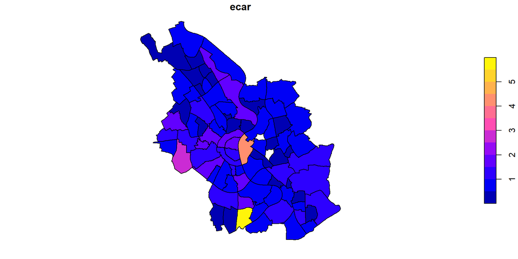

## What makes a good map?

**Good Mapping**

- Reduction to most important information
- Legends, scales, descriptions
- Audience oriented
- Adjusted for color vision deficiencies

**Bad Mapping**

- Overcrowding and overlapping
- Unreadable information
- Missing information like the legend or source
- Poor choice of color palettes

## What makes a good map?

[figure not shown]

[Source](https://media.giphy.com/media/C9x8gX02SnMIoAClXa/giphy-downsized-large.gif)

… but there is one other type:

**The fast but nice map.**

- Fast exploration of spatial data by visualizing the geometries and attributes
- Might not be publication-ready yet, but they are more rewarding than just plotting information

## Our approach: `ggplot2`

`R` offers several packages for mapping spatial data:

Today, we concentrate on [`ggplot2`](https://cran.r-project.org/web/packages/ggplot2/index.html):

- Part of the `tidyverse` — draws on knowledge many of you already have
- Maximum flexibility for customizing every element
- Seamlessly combines maps with other plots in one figure
- Integrates with many extension packages (`tidyterra`, `ggspatial`, …)

## What is `ggplot2`?

`ggplot2` is well-known for creating plots. Thanks to `sf` and `terra`, we can exploit all amazing `ggplot2` functions for spatial data.

In general, on `ggplot2`:

- Well-suited for multi-dimensional data
- Expects data (frames) as input
- Components of the plot are added as layers

```r
plot_call +
  layer_1 +
  layer_2 +
  ... +
  layer_n
```